# Quantifying Climate Change Exposure of Pacific Salmon and Steelhead in Canada

# 3 Temperature thresholds for freshwater stages

There is increasing evidence that salmonids can display considerable intraspecific diversity in thermal tolerance, likely due to local adaptation of populations to their freshwater thermal environments (Eliason et al. 2011; Zillig et al. 2021). This variability makes it difficult to determine an upper stream temperature threshold to quantify the future duration over threshold for freshwater life stages. Data on specific thermal tolerance of Conservation Units (CUs) is limited to a handful of CUs and life stages, limiting the applicability of this specific information in our broad-scale analysis. Further, a recent review highlighted the variability in outcomes under different experimental approaches, and the questionable ecological relevance of some of the reported metrics (Mayer et al. 2023). As such, we decided to rely on temperature guidelines set out by the Province of BC (Oliver and Fidler 2001) that specify a maximum optimal temperature for each species and stage, ignoring potential population-specific deviances.

To ensure the temperature thresholds we applied were not inconsistent with more recent research, we compared the BC Guidelines to the various studies reported on by Mayer et al. (2023) (Tables S2-S6 therein). These studies varied in their ecological relevance critical thermal maximum (CTmax) or upper incipient lethal temperature (UILT), which are considered to have low ecological relevance, to upper temperatures under which salmon can carry out activities essential to survival at any given life-stage (Pejus temperatures), considered to have high ecological relevance. We also show temperatures that are reported to be optimal or the upper observed range of populations in the wild.

There was considerable variability in thermal tolerance reported among studies, due to either population-specific differences or study methodology or both, but the BC Guidelines were not out of range of the thermal tolerance metrics reported by Mayer et al. (2023) (Figures S1 – S5). In general, the BC Guidelines were near upper-optimal or Pejus temepratures, which were considered the most ecologically relevant temperature thresholds by Mayer et al. (2023). The BC Guidelines were far below critical temperatures shown to cause direct mortality. This is consistent with our use and interpretation of the BC Guidelines: we aimed to quantify salmon exposure to temperatures that may have more subtle (sublethal) adverse effects. Mayer et al. (2023) did not report any studies of thermal tolerance for spawning stages or for any life stage of steelhead that could be compared to the BC Guidelines.

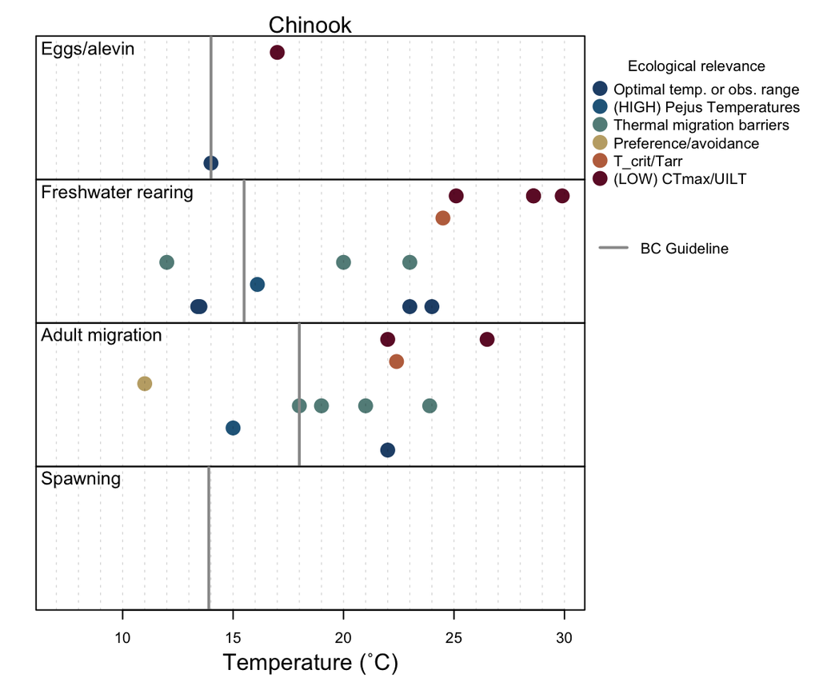

Figure 3.1: Comparison of threshold stream temperatures for salmonid life stages from the BC Guidelines (Oliver and Fidler 2001) to more recently reported estimates of thermal tolerance summarized in Mayer et al. (2023). These other studies are categorized according to the ecological relevance of the approach (see legend and Mayer et al. 2023 for details).

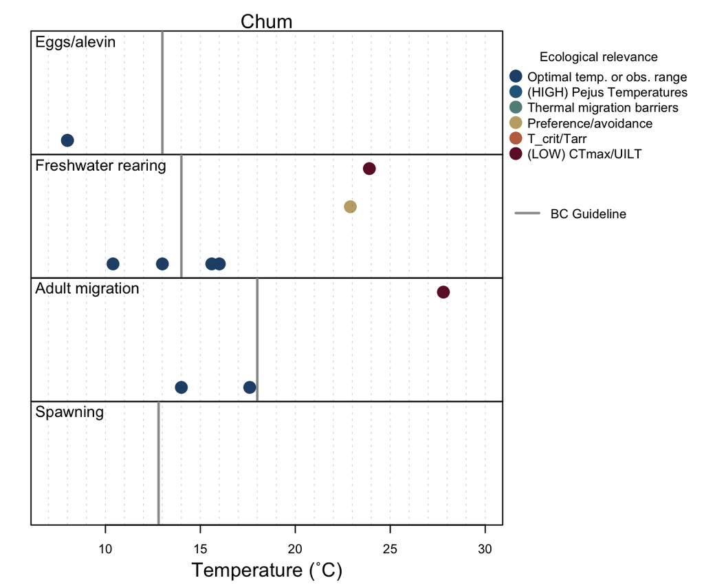

Figure 3.2: Comparison of threshold stream temperatures for salmonid life stages from the BC Guidelines (Oliver and Fidler 2001) to more recently reported estimates of thermal tolerance summarized in Mayer et al. (2023). These other studies are categorized according to the ecological relevance of the approach (see legend and Mayer et al. 2023 for details).

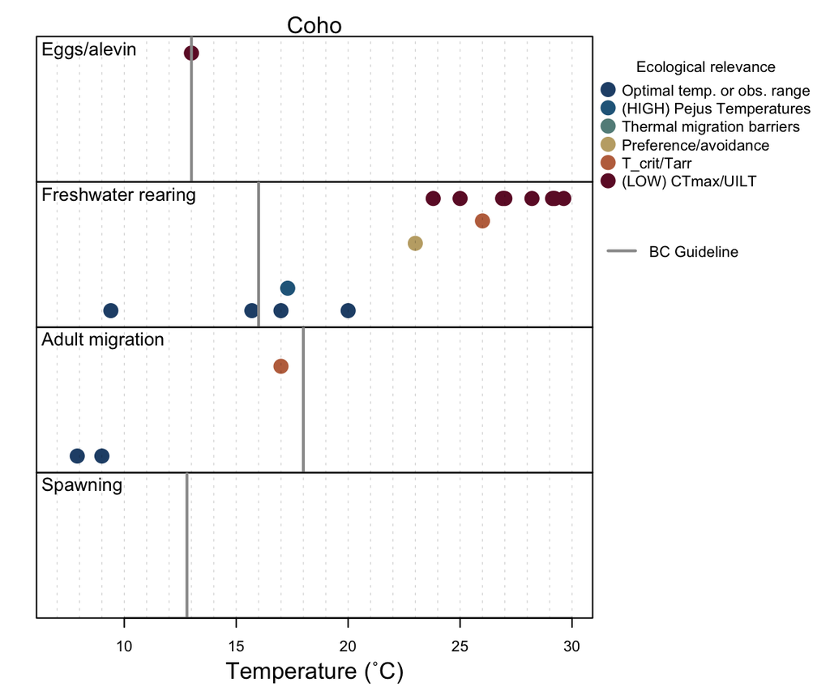

Figure 3.3: Comparison of threshold stream temperatures for salmonid life stages from the BC Guidelines (Oliver and Fidler 2001) to more recently reported estimates of thermal tolerance summarized in Mayer et al. (2023). These other studies are categorized according to the ecological relevance of the approach (see legend and Mayer et al. 2023 for details).

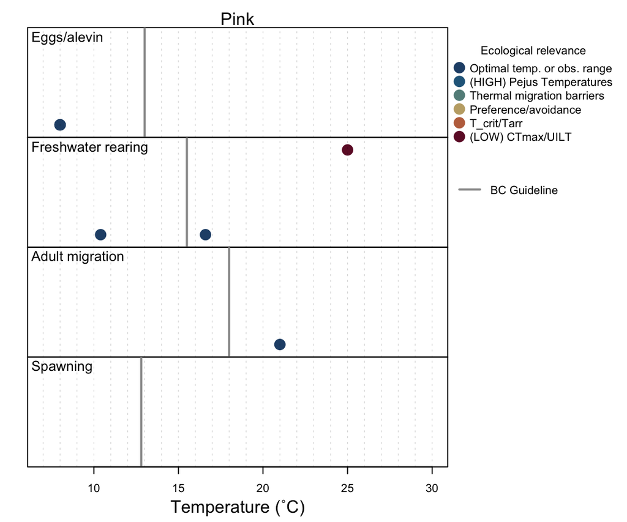

Figure 3.4: Comparison of threshold stream temperatures for salmonid life stages from the BC Guidelines (Oliver and Fidler 2001) to more recently reported estimates of thermal tolerance summarized in Mayer et al. (2023). These other studies are categorized according to the ecological relevance of the approach (see legend and Mayer et al. 2023 for details).

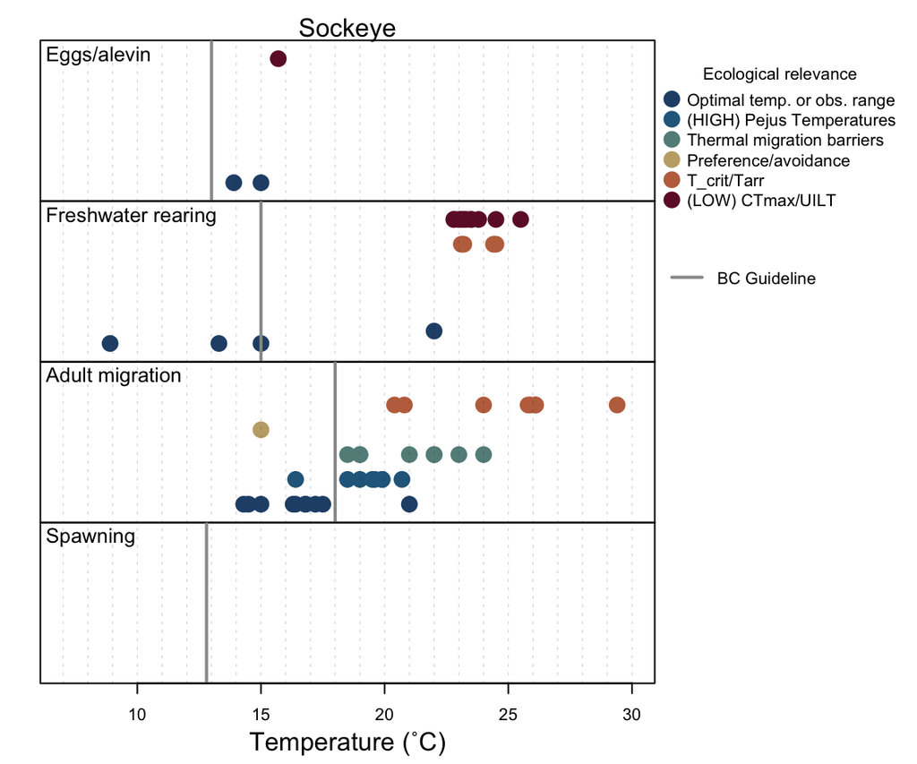

Figure 3.5: Comparison of threshold stream temperatures for salmonid life stages from the BC Guidelines (Oliver and Fidler 2001) to more recently reported estimates of thermal tolerance summarized in Mayer et al. (2023). These other studies are categorized according to the ecological relevance of the approach (see legend and Mayer et al. 2023 for details).

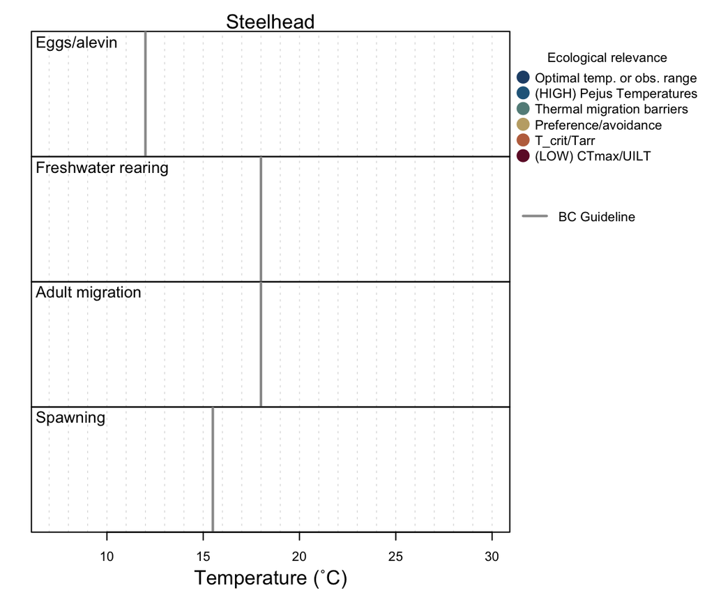

Figure 3.6: Comparison of threshold stream temperatures for salmonid life stages from the BC Guidelines (Oliver and Fidler 2001) to more recently reported estimates of thermal tolerance summarized in Mayer et al. (2023). These other studies are categorized according to the ecological relevance of the approach (see legend and Mayer et al. 2023 for details).

# 4 Migration speeds and distances for lake-type sockeye CUs

The adult freshwater migration stage generally began with freshwater re-entry and extended until the start of spawning. For the adult freshwater migration stage of lake-type sockeye CUs, we considered the period of potential exposure extending for the duration of time it would take sockeye to reach their rearing lake, regardless of when spawning usually began. We based this migration duration on the distance from the ocean entry point to the rearing lake for the CU, with migration rates based on published data by run timing group (English et al. 2005; Quinn 2018). This accounts for the ability of lake-type sockeye CUs, particularly early-migrating CUs, to hold in lakes where they can moderate exposure to high temperatures by moving to deeper water and are not exposed to low flows. The following tables detail the data and sources used to estimate the duration of the adult freshwater migration stage for lake-type sockeye CUs.

**Table S3.** Data sources and values used to calculate the migration duration of lake-type sockeye CUs in the Fraser.

| Stock run timing group | Migration rate (km/day) | Sample size | Reference |
| --- | --- | --- | --- |
| Summer | 43 | 101 | English et al. (2005) Table 5 |
| Late | 20 | 96 | English et al. (2005) Table 5 |
| Early Stuart | 45.8 | NA | Quinn (2018) Table 4.3 |
| Horsefly (ES) | 51.2 | NA | Quinn (2018) Table 4.4 |
| Bowron (ES) | 51.5 | NA | Quinn (2018) Table 4.5 |

***Table S4.** Lake-type sockeye CUs and associated start of freshwater re-entry, run timing group, migration rate (based on run timing group as outlined in Table S3 above), migration distance (calculated from rearing lake to point of ocean entry), and resulting duration of potential exposure.

| Conservation Unit | Start date | Run timing group | Migration rate (km/day) | Migration distance (km) | Duration of potential exposure (days) |
| --- | --- | --- | --- | --- | --- |
| Adams & Momich Lakes-Early Summer | 12-Jul | ES | 52 | 513 | 9.9 |
| Alouette-Early Summer | 12-Jul | ES | 52 | 58 | 1.1 |
| Anderson-Seton-Early Summer | 30-Jun | ES | 52 | 333 | 6.4 |
| Bowron-Early Summer | 12-Jul | ES | 52 | 1103 | 21.2 |
| Chilko-Early Summer | 12-Jul | ES | 52 | 747 | 14.4 |
| Chilko-Summer | 26-Jul | S | 43 | 747 | 17.4 |
| Chilliwack-Early Summer (cyclic) | 30-Jun | ES | 52 | 156 | 3 |
| Cultus-Late | 02-Aug | L | 20 | 111 | 5.6 |
| Francois-Fraser-Summer | 26-Jul | S | 43 | 988 | 23 |
| Harrison-Downstream Migrating-Late | 04-Aug | L | 20 | 127 | 6.4 |

[output cut: 15 more lines]

# 5 Supplemental results

## 5.1 Sea surface salinity

In the main text, we consider exposure of marine life stages to sea surface temperature. Sea surface salinity is another oceanic variable that we considered for inclusion in the exposure assessments. Sea surface salinity can influence stratification and thus nutrient cycling in the ocean, driving bottom-up effects on salmon. Salinity in BC coastal waters has been decreasing since the middle of the last century (Chandler 2022) and long term projections of increased precipitation (Morrison et al. 2014) suggest that this trend will continue. There is some evidence of relationships between salinity and salmon growth or survival Mueter et al. (2005), but no information on thresholds or optimal salinity ranges.

Here, we present supplemental results that include the exposure of marine stages to sea surface salinities lower than the historical range that salmon have experienced. We focus on salinities *below* threshold under the assumption that projected decreases in surface salinity indicate increased stratification and reduced nutrient resupply to surface waters with general negative consequences for salmon (e.g., Thomson et al. 2012). We quantified the number of months below a lower salinity threshold, which we defined for each grid cell as the 2.5th percentile of the modelled historical (1970-1999) salinity. We note, however, that there is some uncertainty about how marine rearing stages will respond, and less saline conditions may have a net benefit for salmon in the open ocean.

In general, exposure to decreasing sea surface salinity was both low and consistent among CUs, offering little information to differentiate overall exposure or prioritise efforts to mediate climate-change impacts on salmon. As such, we opted to exclude these results from the main text, but highlight that more research is needed to understand how to relate proxies of oceanographic change, like sea surface temperature, to salmon survival.

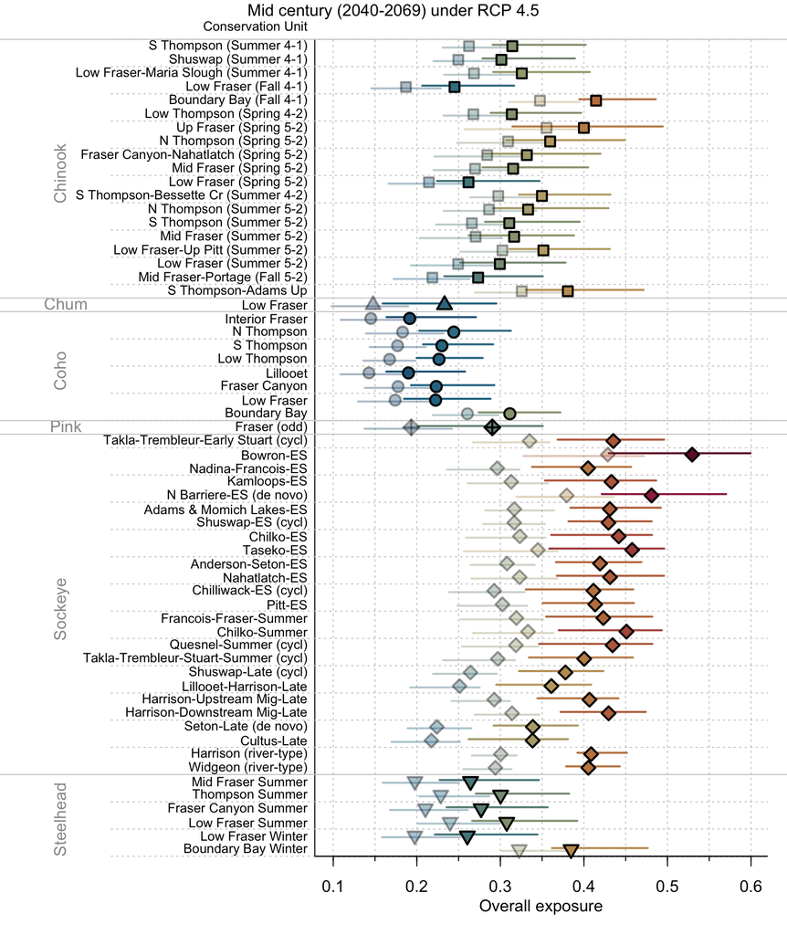

Figure 5.1: Overall exposure to climate changes across the lifecycle (x-axis) for 60 salmon CUs in the Fraser River basin (y-axis) for the mid-century period (2040-2069) under the RCP 4.5 emissions scenario. Points and lines are the median and range in exposure among six different GCMs. Each CU has two version of exposure shown: semi-transparent points are the exposure *including* sea surface salinity for marine stages, and solid points are considering only SST for marine stages (as shwown in the main text). CUs are ordered by species and, within species, by life-history type and approximate distance from the river mouth (starting with the furthest migrating CUs), with numbers and shading corresponding to points in Figure 2. Exposure was calculated as the proportion of the lifecycle that was above or below the thresholds for different climate variables, averaged among variables and life stages for each CU. See below for other periods and emissions scenarios.